# Module Nine Project

For the module nine project you are required to produce coding samples in accordance with the requirements in the project guidelines and rubric. This Notebook has been pre-created as a shell for your project submission.

Once your code is complete, you will download this notebook as an HTML file by clicking **File**, then **Download As**, then **HTML (.html)** from the Jupyter menu bar. Validate that your code and outputs are rendered in the html file before submission.

*Missing Blocks:* Ensure that you have clicked **Run** for all blocks before downloading as an HTML file or the block may be missing from your submission.

### Data Source Information

Below are some example reputable data sources that you can use to collect your minimum of two data sets from:

- https://datasetsearch.research.google.com/
- https://www.kaggle.com/datasets
- https://data.gov/
- https://www.census.gov/data.html
- https://www.bls.gov/data/
- https://databank.worldbank.org/databases
- https://www.ncei.noaa.gov/access/search/index
- https://www.epa.gov/data
- https://www.pewresearch.org/tools-and-datasets/
- https://www.who.int/data/
- https://dataverse.harvard.edu/
- https://search.cdc.gov/search/?query=dataset&dpage=1
- https://data.fivethirtyeight.com/
- https://www.gdeltproject.org/data.html
- https://datahub.io/collections

***Note: this list is not all inclusive, if you have a reputable data set that you have collected, or would like to use, please ensure to upload the data. All data sets will need to be documented in your submission as to the source through the creation of a citation.***

*To Begin:* replace each **data_file_#** entry sample data path with the path to your selected data sets.

You are welcome to use more than two data sets, create an entry for each as applicable for each data set. Ensure that you create comments that provide citations for the data sets you have selected for use. When working through your submission, keep in mind that you will need to have choosen two separate groups of stakeholders to create your final visualizations.

```python
# Data Source 1 (APA-style):
# U.S. Bureau of Labor Statistics. (2024). Unemployment rates for states, 2023 annual averages [Data set].
# Local Area Unemployment Statistics (LAUS).
# https://www.bls.gov/lau/lastrk23.htm
data_file_1 = "/home/codio/workspace/data/sample_use_only/Unemployment2023.csv"
# Note: Course-provided extract used in CS 540 Codio environment.

# Data Source 2 (APA-style):
# U.S. Census Bureau. (2023). NST-EST2023: State population totals and components of change [Data set].
# Population Estimates Program.
# https://www2.census.gov/programs-surveys/popest/datasets/2020-2023/state/totals/NST-EST2023-ALLDATA.csv
data_file_2 = "/home/codio/workspace/data/sample_use_only/PopulationEstimates.csv"
# Note: Course-provided extract used in CS 540 Codio environment.
```

## Installing Required Packages

If you have additional packages that you would like to use or install, add them to the **requirements.txt** file then run the next two blocks.

```python
!pip install --upgrade pip
```

```python
# Note: requirements.txt is empty in this Codio project, so there are no additional packages to install.
!pip install -r requirements.txt
```

## Import the Required Packages

```python
# Import the libraries used throughout this notebook:
# - os: checks file paths and file extensions when loading data
import os
# - numpy/pandas: data cleaning, filtering, grouping, merging
import numpy as np
import pandas as pd
# - matplotlib: required for the project visuals
import matplotlib.pyplot as plt

%matplotlib inline
```

## Loading the Data

Create entries to load your data for your submission.

```python
# This function loads a dataset from a local file path.
# It supports CSV/TXT and Excel files, which keeps the notebook flexible if the dataset format changes.
def load_dataset(path: str) -> pd.DataFrame:
    """Load a dataset from CSV/Excel based on file extension."""
    # Verify the file exists so we get a clear error if the path is wrong.
    if not os.path.exists(path):
        raise FileNotFoundError(f"File not found: {path}")

    # Detect file type by extension and load using the correct pandas reader.
    ext = os.path.splitext(path)[1].lower()
    if ext in [".csv", ".txt"]:
        return pd.read_csv(path)
    if ext in [".xlsx", ".xls"]:
        return pd.read_excel(path)

    # If it is not a supported file type, raise an explicit error.
    raise ValueError(f"Unsupported file type: {ext}")

# Load the two required datasets (Unemployment + Population Estimates).
df1 = load_dataset(data_file_1)
df2 = load_dataset(data_file_2)

# Quick validation: print shapes and preview the first few rows.
print("Dataset 1 shape:", df1.shape)
print("Dataset 2 shape:", df2.shape)

display(df1.head())
display(df2.head())
```

```
Dataset 1 shape: (1184, 5)
Dataset 2 shape: (3238, 5)
```

|  | FIPS_Code | State | Area_Name | Attribute | Value |
| --- | --- | --- | --- | --- | --- |
| 0 | 0 | US | United States | Civilian_labor_force_2019 | 163815894.0 |
| 1 | 0 | US | United States | Employed_2019 | 157805901.0 |
| 2 | 0 | US | United States | Unemployed_2019 | 6009993.0 |
| 3 | 0 | US | United States | Unemployment_rate_2019 | 3.7 |
| 4 | 0 | US | United States | Civilian_labor_force_2020 | 161131754.0 |

|  | FIPStxt | State | Area_Name | Attribute | Value |
| --- | --- | --- | --- | --- | --- |
| 0 | 0 | US | United States | CENSUS_2020_POP | 331449281.0 |
| 1 | 0 | US | United States | ESTIMATES_BASE_2020 | 331464948.0 |
| 2 | 0 | US | United States | POP_ESTIMATE_2020 | 331526933.0 |
| 3 | 0 | US | United States | POP_ESTIMATE_2021 | 332048977.0 |
| 4 | 0 | US | United States | POP_ESTIMATE_2022 | 333271411.0 |

## Examining the Data

Create entries to conduct exploratory data analysis to identify key data points to include relevant data from your two data sets while evaluating the quality of your choosen data.

```python
# This section performs Exploratory Data Analysis (EDA).
# The goal is to understand what each dataset contains, evaluate basic data quality,
# and identify the best fields to use later for merging and visualization.

def examine_dataset(df: pd.DataFrame, name: str, sample_rows: int = 5) -> None:
    """Print EDA + basic quality checks for a dataset."""
    print(f"\n==================== {name} ====================")

    # 1) Quick dataset size check (helps spot unexpected row/column counts)
    print("Shape (rows, cols):", df.shape)

    # 2) Preview the first few rows (helps confirm the data loaded correctly)
    display(df.head(sample_rows))

    # 3) Show column names and types (important for merge planning + numeric conversions)
    print("\nColumn names:")
    print(df.columns.tolist())

    print("\nData types:")
    display(df.dtypes)

    # 4) Missing values (count + percentage)
    # This helps identify columns that may need cleaning or may not be reliable for analysis.
    missing = df.isna().sum()
    missing_pct = (missing / len(df) * 100).round(2)
    missing_report = (
        pd.DataFrame({"missing_count": missing, "missing_pct": missing_pct})
        .sort_values("missing_count", ascending=False)
    )
    print("\nMissing values (top 15):")
    display(missing_report.head(15))

    # 5) Duplicate rows (basic quality signal)
    dup_rows = df.duplicated().sum()
    print(f"\nDuplicate rows: {dup_rows}")

    # 6) Numeric summary + outlier scan (if numeric columns exist)
    # Outliers can be legitimate, but it’s important to know they are present before charting.
    num_cols = df.select_dtypes(include=[np.number]).columns.tolist()
    if num_cols:
        print("\nNumeric summary (describe):")
        display(df[num_cols].describe().T)

        print("\nPotential outlier scan (IQR method) for first up to 5 numeric columns:")
        for col in num_cols[:5]:
            series = df[col].dropna()
            if len(series) < 10:
                continue

            q1 = series.quantile(0.25)
            q3 = series.quantile(0.75)
            iqr = q3 - q1
            lower = q1 - 1.5 * iqr
            upper = q3 + 1.5 * iqr
            outliers = ((series < lower) | (series > upper)).sum()

            print(f" - {col}: outliers={outliers:,} (lower={lower:.3f}, upper={upper:.3f})")
    else:
        print("\nNo numeric columns detected for summary/outlier scan.")

    # 7) Merge key clues (helps pick a reliable join field for blending)
    # This doesn’t merge yet; it just identifies likely candidates like state/FIPS/year.
    common_keys = ["state", "state_name", "state_code", "statecode", "fips", "fipstxt", "county", "year", "date"]
    found_keys = [k for k in common_keys if k in [c.lower() for c in df.columns.astype(str)]]
    print("\nPossible merge key clues found:", found_keys if found_keys else "None detected")


# Run EDA on both datasets (Unemployment + Population)
examine_dataset(df1, "Dataset 1 (Unemployment 2023)")
examine_dataset(df2, "Dataset 2 (Population Estimates)")

# -----------------------------
# Data Quality Summary (for narrative)
# -----------------------------
missing_df1 = df1.isna().sum().sum()
missing_df2 = df2.isna().sum().sum()
dups_df1 = df1.duplicated().sum()
dups_df2 = df2.duplicated().sum()

print("Data quality summary:")
print(f" - Dataset 1 missing values (total): {missing_df1}")
print(f" - Dataset 2 missing values (total): {missing_df2}")
print(f" - Dataset 1 duplicate rows: {dups_df1}")
print(f" - Dataset 2 duplicate rows: {dups_df2}")
print("Note: Potential outliers in numeric columns are expected because the extract includes a national total (US) row and")
print("large-population states/territories that naturally create extreme values in counts and totals.")
```

```
==================== Dataset 1 (Unemployment 2023) ====================
Shape (rows, cols): (1184, 5)
```

|  | FIPS_Code | State | Area_Name | Attribute | Value |
| --- | --- | --- | --- | --- | --- |
| 0 | 0 | US | United States | Civilian_labor_force_2019 | 163815894.0 |
| 1 | 0 | US | United States | Employed_2019 | 157805901.0 |
| 2 | 0 | US | United States | Unemployed_2019 | 6009993.0 |
| 3 | 0 | US | United States | Unemployment_rate_2019 | 3.7 |
| 4 | 0 | US | United States | Civilian_labor_force_2020 | 161131754.0 |

```
Column names:
['FIPS_Code', 'State', 'Area_Name', 'Attribute', 'Value']

Data types:
```

```
FIPS_Code      int64
State         object
Area_Name     object
Attribute     object
Value        float64
dtype: object
```

```
Missing values (top 15):
```

|  | missing_count | missing_pct |
| --- | --- | --- |
| FIPS_Code | 0 | 0.0 |
| State | 0 | 0.0 |
| Area_Name | 0 | 0.0 |
| Attribute | 0 | 0.0 |
| Value | 0 | 0.0 |

```
Duplicate rows: 0

Numeric summary (describe):
```

|  | count | mean | std | min | 25% | 50% | 75% | max |
| --- | --- | --- | --- | --- | --- | --- | --- | --- |
| FIPS_Code | 1184.0 | 2.864951e+04 | 1.672579e+04 | 0.0 | 15000.0 | 28000.0 | 42000.00 | 72000.0 |
| Value | 1184.0 | 2.777221e+06 | 1.474921e+07 | 1.0 | 100.0 | 208283.5 | 1843830.25 | 166689556.0 |

```
Potential outlier scan (IQR method) for first up to 5 numeric columns:
 - FIPS_Code: outliers=0 (lower=-25500.000, upper=82500.000)
 - Value: outliers=118 (lower=-2765495.375, upper=4609425.625)

Possible merge key clues found: ['state']

==================== Dataset 2 (Population Estimates) ====================
Shape (rows, cols): (3238, 5)
```

|  | FIPStxt | State | Area_Name | Attribute | Value |
| --- | --- | --- | --- | --- | --- |
| 0 | 0 | US | United States | CENSUS_2020_POP | 331449281.0 |
| 1 | 0 | US | United States | ESTIMATES_BASE_2020 | 331464948.0 |
| 2 | 0 | US | United States | POP_ESTIMATE_2020 | 331526933.0 |
| 3 | 0 | US | United States | POP_ESTIMATE_2021 | 332048977.0 |
| 4 | 0 | US | United States | POP_ESTIMATE_2022 | 333271411.0 |

```
Column names:
['FIPStxt', 'State', 'Area_Name', 'Attribute', 'Value']

Data types:
```

```
FIPStxt        int64
State         object
Area_Name     object
Attribute     object
Value        float64
dtype: object
```

```
Missing values (top 15):
```

|  | missing_count | missing_pct |
| --- | --- | --- |
| FIPStxt | 0 | 0.0 |
| State | 0 | 0.0 |
| Area_Name | 0 | 0.0 |
| Attribute | 0 | 0.0 |
| Value | 0 | 0.0 |

```
Duplicate rows: 0

Numeric summary (describe):
```

|  | count | mean | std | min | 25% | 50% | 75% | max |
| --- | --- | --- | --- | --- | --- | --- | --- | --- |
| FIPStxt | 3238.0 | 2.817914e+04 | 1.612471e+04 | 0.0 | 15000.0 | 28000.0 | 41000.00 | 72000.0 |
| Value | 3238.0 | 1.271806e+06 | 1.457433e+07 | -458862.0 | 2.0 | 1345.0 | 41949.75 | 334914895.0 |

```
Potential outlier scan (IQR method) for first up to 5 numeric columns:
 - FIPStxt: outliers=0 (lower=-24000.000, upper=80000.000)
 - Value: outliers=604 (lower=-62919.625, upper=104871.375)

Possible merge key clues found: ['state', 'fipstxt']
Data quality summary:
 - Dataset 1 missing values (total): 0
 - Dataset 2 missing values (total): 0
 - Dataset 1 duplicate rows: 0
 - Dataset 2 duplicate rows: 0
Note: Potential outliers in numeric columns are expected because the extract includes a national total (US) row and
large-population states/territories that naturally create extreme values in counts and totals.
```

## Data Preprocessing Techniques

Create entries to clean and blend your data sets as applicable consolidating the two or more data sets into a single collection for inclusion into your visualizations.

```python
# This section cleans and blends the unemployment + population datasets into ONE state-level table.
# Why: stakeholder visuals need one row per state with clear metric columns
# (ex: Unemployment_rate_2023, POP_ESTIMATE_2023).

def clean_columns(df: pd.DataFrame) -> pd.DataFrame:
    """Standardize column names and trim whitespace for consistent merges and filtering."""
    df = df.copy()

    # Standardize column names (lowercase + underscores)
    df.columns = (
        df.columns.astype(str)
        .str.strip()
        .str.lower()
        .str.replace(" ", "_", regex=False)
        .str.replace("-", "_", regex=False)
    )

    # Strip whitespace from text fields (common issue in geographic labels)
    for col in df.select_dtypes(include=["object"]).columns:
        df[col] = df[col].astype(str).str.strip()

    return df

# Clean both datasets
df1_clean = clean_columns(df1)
df2_clean = clean_columns(df2)

# Pivot each dataset from long format (Attribute/Value) into wide format (one column per attribute).
# Result: one row per state (plus US), many metric columns.
unemp_wide = (
    df1_clean.pivot_table(index="state", columns="attribute", values="value", aggfunc="mean")
    .reset_index()
)
pop_wide = (
    df2_clean.pivot_table(index="state", columns="attribute", values="value", aggfunc="mean")
    .reset_index()
)

# --- IMPORTANT: Clean up pivot header name for HTML readability ---
# Without this, pandas may display "attribute" as a header label in the HTML export.
unemp_wide.columns.name = None
pop_wide.columns.name = None

integrated_df = pd.merge(unemp_wide, pop_wide, on="state", how="inner")

# Merge key clarity (helps reviewers understand why the join is valid)
print("Merge key note: 'state' uses USPS-style abbreviations (e.g., CA, TX) consistently across both extracts.")

print("Integrated (state-level) dataset shape:", integrated_df.shape)
display(integrated_df.head())

print("Blend note: Datasets were merged using the 'state' abbreviation field (e.g., CA, TX), which is shared across both sources.")
print("This creates a single state-level record per geography after pivoting attributes into columns.")

# -----------------------------
# Modeling note (multi-level data modeling)
# -----------------------------
print("Modeling note: Both datasets are converted from long format (Attribute/Value) to wide format (one column per attribute).")
print("This creates a state-level integrated table suitable for stakeholder dashboards and cross-metric comparison.")

# -----------------------------
# Quick validation of key metrics needed for visuals
# -----------------------------
key_metrics = ["Unemployment_rate_2023", "POP_ESTIMATE_2023"]
present = [m for m in key_metrics if m in integrated_df.columns]
missing_metrics = [m for m in key_metrics if m not in integrated_df.columns]

print("\nKey metric check:")
print(" - Present:", present)
print(" - Missing:", missing_metrics if missing_metrics else "None")
```

```
Merge key note: 'state' uses USPS-style abbreviations (e.g., CA, TX) consistently across both extracts.
Integrated (state-level) dataset shape: (53, 91)
```

|  | state | Civilian_labor_force_2019 | Civilian_labor_force_2020 | Civilian_labor_force_2021 | Civilian_labor_force_2022 | Civilian_labor_force_2023 | Employed_2019 | Employed_2020 | Employed_2021 | Employed_2022 | ... | R_INTERNATIONAL_MIG_2023 | R_NATURAL_CHG_2021 | R_NATURAL_CHG_2022 | R_NATURAL_CHG_2023 | R_NET_MIG_2021 | R_NET_MIG_2022 | R_NET_MIG_2023 | Rural_Urban_Continuum_Code_2013 | Rural_Urban_Continuum_Code_2023_y | Urban_Influence_2013 |
| --- | --- | --- | --- | --- | --- | --- | --- | --- | --- | --- | --- | --- | --- | --- | --- | --- | --- | --- | --- | --- | --- |
| 0 | AK | 352029.0 | 346552.0 | 351520.0 | 353692.0 | 357094.0 | 332197.0 | 317678.0 | 329147.0 | 338729.0 | ... | 2.7 | 5.6 | 4.1 | 5.0 | -2.8 | -6.6 | -4.8 | NaN | NaN | NaN |
| 1 | AL | 2271835.0 | 2263144.0 | 2249514.0 | 2276362.0 | 2308131.0 | 2199379.0 | 2118600.0 | 2173978.0 | 2218627.0 | ... | 1.1 | -2.4 | -1.8 | -0.3 | 5.9 | 6.5 | 7.1 | NaN | NaN | NaN |
| 2 | AR | 1353175.0 | 1340557.0 | 1330676.0 | 1359540.0 | 1377657.0 | 1305858.0 | 1257949.0 | 1276933.0 | 1315886.0 | ... | 1.3 | -1.7 | -1.3 | -0.3 | 6.3 | 7.3 | 7.3 | NaN | NaN | NaN |
| 3 | AZ | 3432400.0 | 3471339.0 | 3525449.0 | 3599531.0 | 3690974.0 | 3267548.0 | 3200219.0 | 3347264.0 | 3462671.0 | ... | 2.9 | -0.6 | -0.1 | 1.0 | 12.5 | 12.6 | 7.8 | NaN | NaN | NaN |
| 4 | CA | 19385262.0 | 18958604.0 | 18956575.0 | 19169341.0 | 19308287.0 | 18589551.0 | 17037036.0 | 17568743.0 | 18348916.0 | ... | 3.9 | 1.7 | 2.7 | 2.9 | -10.5 | -5.3 | -4.8 | NaN | NaN | NaN |

5 rows × 91 columns

```
Blend note: Datasets were merged using the 'state' abbreviation field (e.g., CA, TX), which is shared across both sources.
This creates a single state-level record per geography after pivoting attributes into columns.
Modeling note: Both datasets are converted from long format (Attribute/Value) to wide format (one column per attribute).
This creates a state-level integrated table suitable for stakeholder dashboards and cross-metric comparison.

Key metric check:
 - Present: ['Unemployment_rate_2023', 'POP_ESTIMATE_2023']
 - Missing: None
```

## Data Visualizations

Create entries to visualize your data using appropriate visualization types to reveal key trends within the data collection. Integrate multiple data attributes into visualizations using appropriate techniques to derive key insights from your visualizations. In your data visualizations, you will use multi-level data modeling practices to refine your visualizations. Your visualizations should include a high-level visualization that provides a broad overview of the data for one of your two stakeholders, as well as a detailed, insight-focused visualization that highlights the key findings for the other of your two stakeholders.

```
Visualization dataset shape: (52, 3)
```

|  | state | unemployment_rate | population |
| --- | --- | --- | --- |
| 0 | AK | 4.2 | 733406.0 |
| 1 | AL | 2.5 | 5108468.0 |
| 2 | AR | 3.3 | 3067732.0 |
| 3 | AZ | 3.9 | 7431344.0 |
| 4 | CA | 4.8 | 38965193.0 |

```
Stakeholder A (Leadership): Overview ranking of unemployment rate (2023).
```

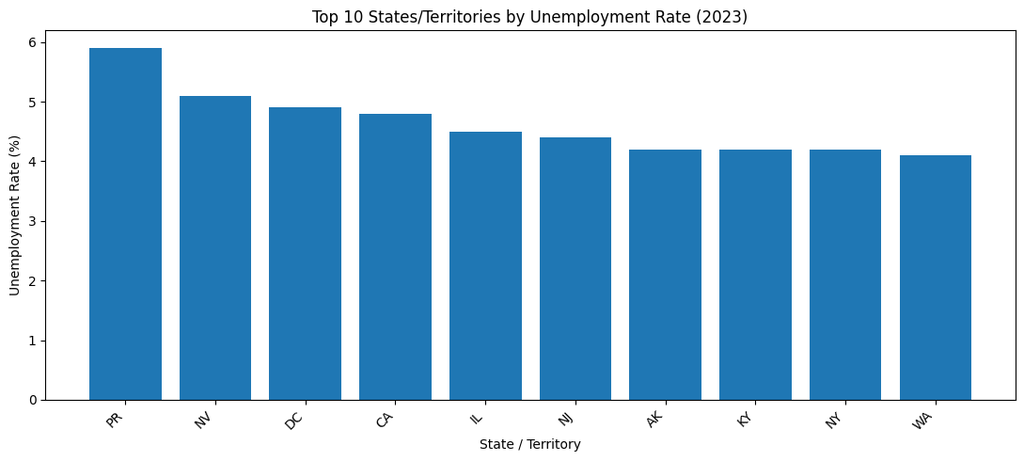

```
Stakeholder B (Operations/Analyst): Relationship view to spot clusters/outliers (unemployment vs population).
```

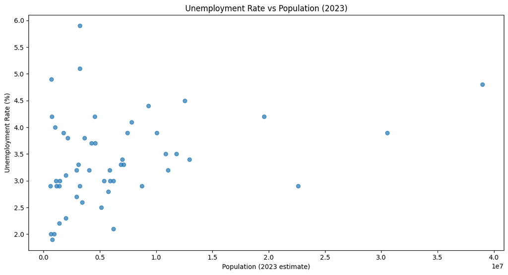

```
Key callouts (Top 5 unemployment-rate states/territories):
```

|  | state | unemployment_rate | population |
| --- | --- | --- | --- |
| 39 | PR | 5.9 | 3205691.0 |
| 33 | NV | 5.1 | 3194176.0 |
| 7 | DC | 4.9 | 678972.0 |
| 4 | CA | 4.8 | 38965193.0 |
| 14 | IL | 4.5 | 12549689.0 |

```
Insight: Highest unemployment-rate areas in 2023 include PR, NV, DC, CA, IL.
Insight: The population vs unemployment scatter suggests unemployment is not strictly driven by population size, with outliers appearing among both small and large populations.
```

```python
# -------------------------------------------------------------------
# Data Visualizations (two stakeholder views)
# -------------------------------------------------------------------
# Stakeholder A (Leadership): quick ranking of highest unemployment (2023).
# Stakeholder B (Operations/Analyst): relationship view (unemployment vs population) to spot clusters/outliers.
#
# Note: integrated_df was created in preprocessing by pivoting both datasets to "wide" format
# and then merging them on state. Key metrics should exist as columns like:
# - Unemployment_rate_2023   (already stored as a percent value, e.g., 4.8 means 4.8%)
# - POP_ESTIMATE_2023

# --- Cosmetic cleanup for HTML readability ---
# (Extra safety: if integrated_df ever regains a columns name, remove it.)
integrated_df.columns.name = None

# 1) Pick the exact columns we want for this story.
unemp_col = "Unemployment_rate_2023"
pop_col = "POP_ESTIMATE_2023"

# 2) Validate the columns exist (prevents confusing KeyErrors).
required_cols = ["state", unemp_col, pop_col]
missing = [c for c in required_cols if c not in integrated_df.columns]
if missing:
    raise ValueError(
        f"Missing expected columns in integrated_df: {missing}. "
        f"Available columns include: {integrated_df.columns.tolist()[:25]} ..."
    )

# 3) Build a clean visualization dataframe (one row per state).
viz_df = integrated_df[required_cols].copy()

# Remove national total row so state comparisons are meaningful.
viz_df = viz_df[viz_df["state"].str.upper() != "US"].copy()

# Convert to numeric + drop blanks so charts don’t silently mislead.
viz_df[unemp_col] = pd.to_numeric(viz_df[unemp_col], errors="coerce")
viz_df[pop_col] = pd.to_numeric(viz_df[pop_col], errors="coerce")
viz_df = viz_df.dropna(subset=[unemp_col, pop_col])

# Rename for readability in charts + narrative.
viz_df = viz_df.rename(columns={unemp_col: "unemployment_rate", pop_col: "population"})

print("Visualization dataset shape:", viz_df.shape)
display(viz_df.head())

# -----------------------------
# High-level visualization (Leadership)
# -----------------------------
print("Stakeholder A (Leadership): Overview ranking of unemployment rate (2023).")

top_n = 10
top_states = viz_df.sort_values("unemployment_rate", ascending=False).head(top_n)

plt.figure(figsize=(11, 5))
plt.bar(top_states["state"], top_states["unemployment_rate"])
plt.xticks(rotation=45, ha="right")
plt.title(f"Top {top_n} States/Territories by Unemployment Rate (2023)")
plt.xlabel("State / Territory")
plt.ylabel("Unemployment Rate (%)")  # Values already represent percent
plt.tight_layout()
plt.show()

# -----------------------------
# Detailed visualization (Operations/Analyst)
# -----------------------------
print("Stakeholder B (Operations/Analyst): Relationship view to spot clusters/outliers (unemployment vs population).")

plt.figure(figsize=(11, 6))
plt.scatter(viz_df["population"], viz_df["unemployment_rate"], alpha=0.7)
plt.title("Unemployment Rate vs Population (2023)")
plt.xlabel("Population (2023 estimate)")
plt.ylabel("Unemployment Rate (%)")  # Values already represent percent
plt.tight_layout()
plt.show()

# 4) Callouts for your narrative (top 5 unemployment-rate states/territories).
outliers = viz_df.sort_values("unemployment_rate", ascending=False).head(5)
print("Key callouts (Top 5 unemployment-rate states/territories):")
display(outliers)

print(f"Insight: Highest unemployment-rate areas in 2023 include {', '.join(outliers['state'].tolist())}.")
print(
    "Insight: The population vs unemployment scatter suggests unemployment is not strictly driven by population size, "
    "with outliers appearing among both small and large populations."
)
```